# Modeling Time Series of Monthly Air Passenger Data

Sean Schilk

11/23/2025

This assignment focuses on the conceptual understanding of decomposing time series and forecasting with decomposing. Old observations will introduce bias and lead to poorer forecasting performance, so we will use a data set with about 150-200 recent observations.

```r
#?AirPassengers
data("AirPassengers")
```

Our data set includes the monthly totals of internatuonal airline passengers, from 1949 to 1960.

First lets define the time series object. Since this is monthly data, frequency =12 will be used the define the time series object.

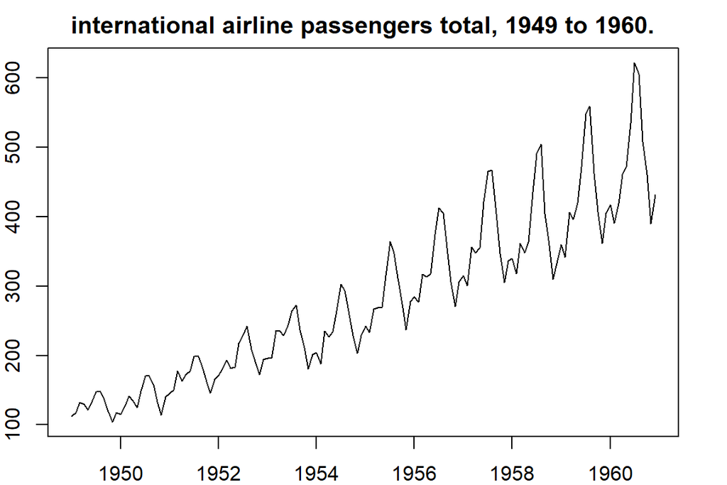

```r
AirPassengers.ts = ts(AirPassengers, frequency = 12, start = c(1949, 1))
par(mar=c(2,2,2,2))
plot(AirPassengers.ts, main="international airline passengers total, 1949 to 1960.", ylab="Monthly Rate", xlab="")
```

# 1 Forecasting with Decomposing

The following visual representations show the different behaviors of the two methods of decomposition:

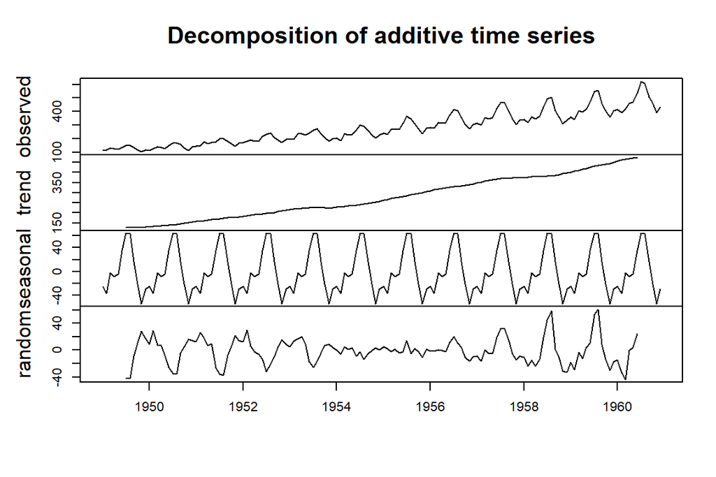

```r
cls.decomp = decompose(AirPassengers.ts)
par(mar=c(2,2,2,2))
plot(cls.decomp, xlab="")
```

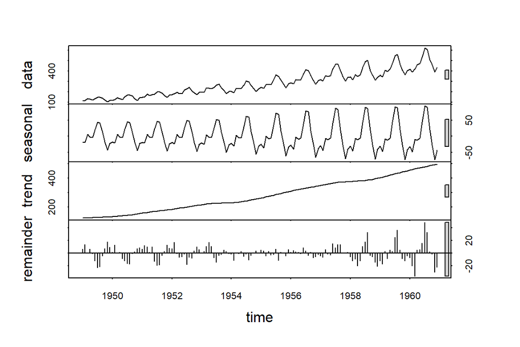

```r
stl.decomp=stl(AirPassengers.ts, s.window = 12)
par(mar=c(2,2,2,2))
plot(stl.decomp)
```

Notice that the classical decomposition method does not work as well as the STL method due to the robustness of the LOESS component.

We hold up the last 7 periods of data for testing. The rest of the historical data will be used to train the forecast model.

```r
library(forecast)
ini.data = AirPassengers
n0 = length(ini.data)
train.data01 = AirPassengers[1:(n0-7)]
train.data02 = AirPassengers[37:(n0-7)]
train.data03 = AirPassengers[73:(n0-7)]
train.data04 = AirPassengers[97:(n0-7)]
## last 7 observations
test.data = AirPassengers[(n0-6):n0]
train01.ts = ts(train.data01, frequency = 12, start = c(1949, 1))
train02.ts = ts(train.data02, frequency = 12, start = c(1952, 1))
train03.ts = ts(train.data03, frequency = 12, start = c(1955, 1))
train04.ts = ts(train.data04, frequency = 12, start = c(1957, 1))
stl01 = stl(train01.ts, s.window = 12)
stl02 = stl(train02.ts, s.window = 12)
stl03 = stl(train03.ts, s.window = 12)
stl04 = stl(train04.ts, s.window = 12)
## Forecast with decomposing
fcst01 = forecast(stl01,h=7, method="naive")
fcst02 = forecast(stl02,h=7, method="naive")
fcst03 = forecast(stl03,h=7, method="naive")
fcst04 = forecast(stl04,h=7, method="naive")
```

We next perform error analysis.

```r
library(knitr)
## To compare different errors, we will not use the percentage for MAPE
PE01=(test.data-fcst01$mean)/fcst01$mean
PE02=(test.data-fcst02$mean)/fcst02$mean
PE03=(test.data-fcst03$mean)/fcst03$mean
PE04=(test.data-fcst04$mean)/fcst04$mean
###
MAPE1 = mean(abs(PE01))
MAPE2 = mean(abs(PE02))
MAPE3 = mean(abs(PE03))
MAPE4 = mean(abs(PE04))
###
E1=test.data-fcst01$mean
E2=test.data-fcst02$mean
E3=test.data-fcst03$mean
E4=test.data-fcst04$mean
MSE1=mean(E1^2)
MSE2=mean(E2^2)
MSE3=mean(E3^2)
MSE4=mean(E4^2)
###
MSE=c(MSE1, MSE2, MSE3, MSE4)
MAPE=c(MAPE1, MAPE2, MAPE3, MAPE4)
accuracy=cbind(MSE=MSE, MAPE=MAPE)
row.names(accuracy)=c("n.137", "n.101", "n. 65", "n. 41")
kable(accuracy, caption="Error comparison between forecast results with different sample sizes")
```

Error comparison between forecast results with different sample sizes

|  | MSE | MAPE |
| --- | --- | --- |
| n.137 | 1191.9089 | 0.0533261 |
| n.101 | 858.2857 | 0.0444797 |
| n. 65 | 542.5456 | 0.0344187 |
| n. 41 | 280.5487 | 0.0246638 |

Let’s see a visual comparison:

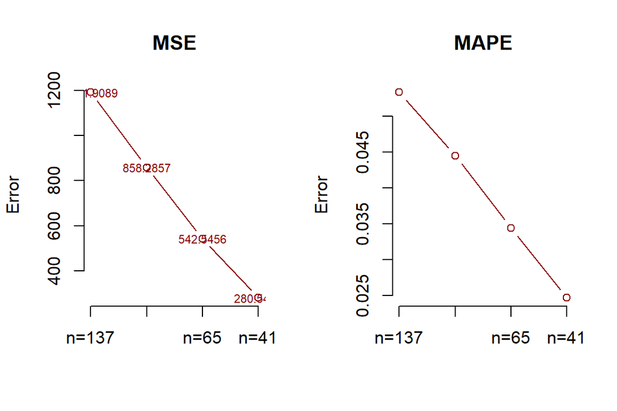

````r
par(mfrow=c(1,2))
plot(1:4, MSE, type="b", col="darkred", ylab="Error", xlab="",
     #ylim=c(0.4,.85),xlim = c(0.5,4.5),
     main="MSE", axes=FALSE)
labs=c("n=137", "n=101", "n=65", "n=41")
axis(1, at=1:4, label=labs)
axis(2)
#lines(1:4, MAPE, type="b", col="blue")
text(1:4, MAPE+0.03, as.character(round(MAPE,4)), col="blue", cex=0.7)
text(1:4, MSE-0.03, as.character(round(MSE,4)), col="darkred", cex=0.7)
legend(1.5, 0.63, c("MSE", "MAPE"), col=c("darkred","blue"), lty=1, bty="n", cex=0.7)
###
#```{r fig.align='center', fig.cap= "Comparing forecast errors", fig.width=5, fig.height=3.5}
plot(1:4, MAPE, type="b", col="darkred", ylab="Error", xlab="",
     #ylim=c(0.4,.85),xlim = c(0.5,4.5),
     main="MAPE", axes=FALSE)
labs=c("n=137", "n=101", "n=65", "n=41")
axis(1, at=1:4, label=labs)
axis(2)
````

We trained the same algorithm with different sample sizes and compared the resulting accuracy measures. Among four training sizes 137, 101, 65, 41. Lower MSE and MAPE are better, so based strictly on these metrics, the model trained on 41 observations performed best.

This enforces the idea further that older observations are not always useful if the process changes over time.